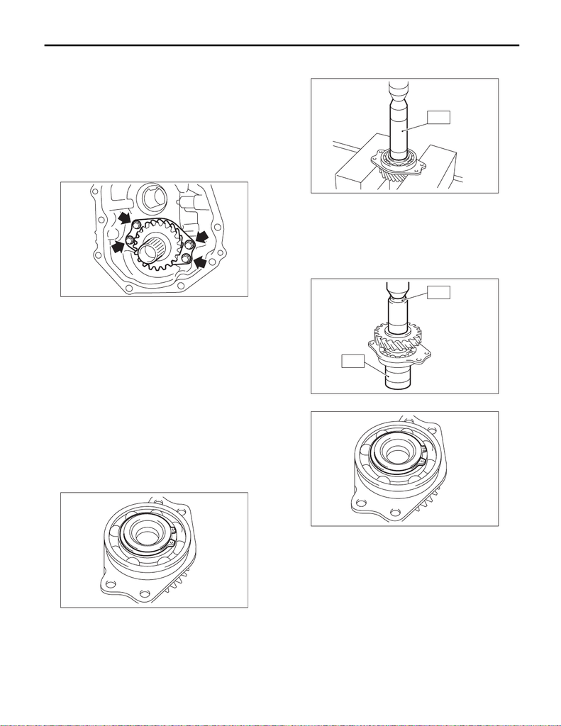

6MT(TY85)-52

Transfer Drive Gear

MANUAL TRANSMISSION AND DIFFERENTIAL

15.Transfer Drive Gear

A: REMOVAL

1) Remove the manual transmission assembly

from the vehicle. <Ref. to 6MT(TY85)-31, REMOV-

AL, Manual Transmission Assembly.>

2) Prepare the transmission for overhaul. <Ref. to

6MT(TY85)-38, Preparation for Overhaul.>

3) Remove the extension case. <Ref. to

6MT(TY85)-42, REMOVAL, Extension Case.>

4) Remove the transfer drive gear.

B: INSTALLATION

1) Install the transfer drive gear.

Tightening torque:

25 N·m (2.5 kgf-m, 18.4 ft-lb)

2) When the ball bearing, transfer drive gear or

snap ring are replaced, select an appropriate ad-

justing washer for the transfer drive gear. <Ref. to

6MT(TY85)-43, ASSEMBLY, Extension Case.>

3) Install the extension case. <Ref. to 6MT(TY85)-

42, INSTALLATION, Extension Case.>

4) Install the manual transmission assembly to the

vehicle. <Ref. to 6MT(TY85)-33, INSTALLATION,

Manual Transmission Assembly.>

C: DISASSEMBLY

1) Remove the snap ring.

2) Remove the bearing using the ST.

ST 499877000 RACE 4-5 INSTALLER

D: ASSEMBLY

1) Using the ST, install the ball bearing.

NOTE:

Use a new ball bearing.

ST1 499247400 INSTALLER

ST2 398497701 SEAT

2) Install the snap ring.

3) Inspect the clearance between the snap ring and

the ball bearing. <Ref. to 6MT(TY85)-53, INSPEC-

TION, Transfer Drive Gear.>

MT-00505

MT-00506

MT-00507

ST

MT-00508

ST2

ST1

MT-00506

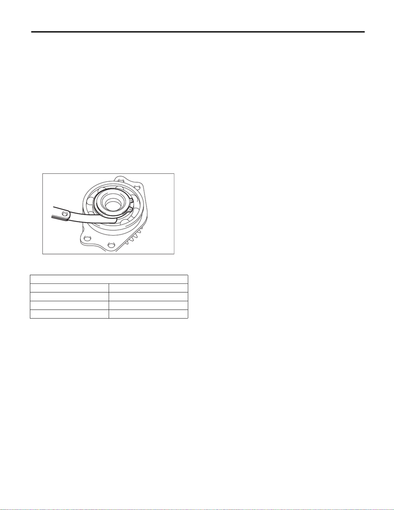

6MT(TY85)-53

Transfer Drive Gear

MANUAL TRANSMISSION AND DIFFERENTIAL

E: INSPECTION

1) Bearing

Replace the bearings in the following cases.

• Damage or rust on the bearings

• Wear, or damage

• The bearing does not rotate smoothly or an ab-

normal noise is emitted.

2) Drive gear

Replace the drive gear in following case:

• If the drive gear tooth surface and shaft are ex-

cessively damaged or broken.

3) Measure the clearance between the snap ring

and ball bearing inner race with a thickness gauge.

Standard clearance between the snap ring and

inner race:

0 — 0.15 mm (0 — 0.0059 in)

4) If the measurement is out of specifications, rese-

lect an appropriate snap ring.

After replacing the snap ring, reinspect the clear-

ance.

Snap ring

Part No. Thickness mm (in)

805045050 1.76 (0.069)

805045060 1.88 (0.074)

805045070 2.00 (0.079)

MT-00509